# Affective theory of mind impairments underlying callous-unemotional traits and the role of cognitive control: A pilot study

## 6.3 Figures

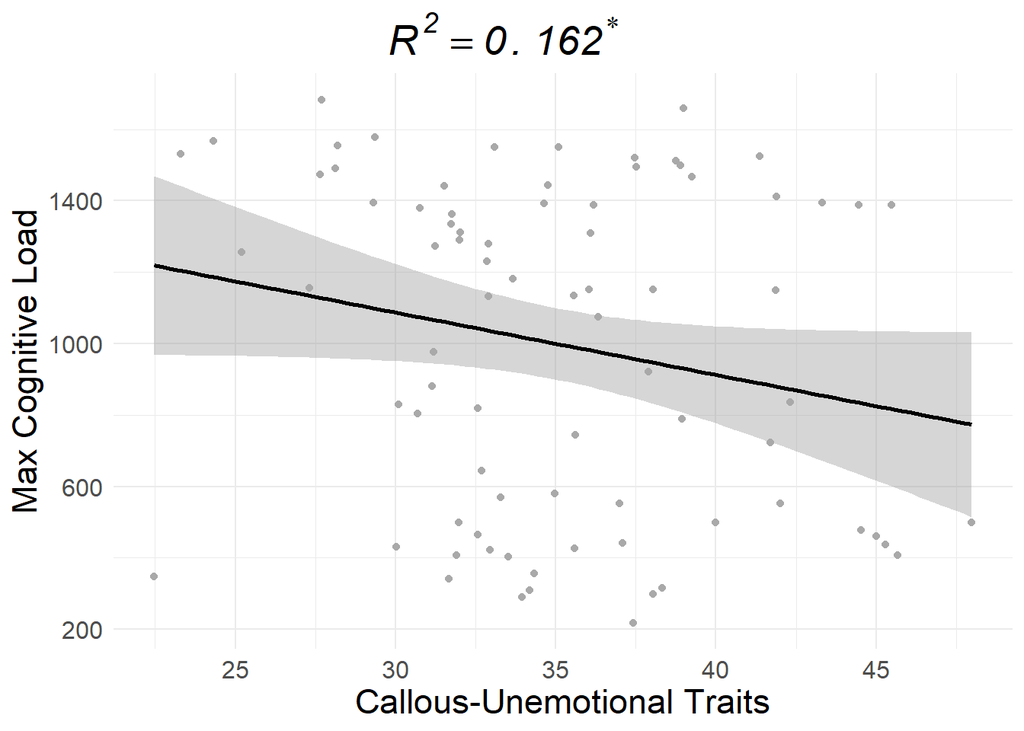

```r
icu<-resid(lm(icu_total ~
            sex_male +
            age +
            race_White +
            sdq_total_cd +
            bad_resp2, data=T2_dat))

load<-resid(lm(load1_max ~
            sex_male +
            age +
            race_White +
            sdq_total_cd +
            bad_resp2, data=T2_dat))
dat<-data.frame(icu,load)


library(latex2exp)
ggplot(dat,aes(x=icu,y=load)) +
  geom_smooth(method="lm",col="black",formula ='y ~ x') +
  geom_point(color="dark grey")+
  theme_minimal()+
  scale_y_continuous("Max Cognitive Load",n.breaks =  6, labels = c("200","600","1000","1400","1800")) +# ,n.breaks =  6, labels = c("200","600","1000","1400","1800")
  scale_x_continuous("Callous-Unemotional Traits",n.breaks = 5, labels = c("20", "25", "30", "35","40", "45", "4")) + #,n.breaks = 5, labels = c("20", "25", "30", "35","40", "45", "4")
  labs(title = TeX("$\\;$ $\\;$ $\\;$ $\\;$ $\\;$ $\\;$ $\\;$ $\\;$ $\\textit{R^2} = $\\textit{0.162^*}"))+
  theme(axis.text=element_text(size=rel(1.1)),axis.title=element_text(size=17),title =element_text(size=17))
```

```r
## 450x450 or 4.5 x 4.5 in "in" units
#ggsave(path = "C:\\Users\\wintersd\\OneDrive - The University of Colorado Denver\\DPRG main project\\Analyses and Data\\full_data_87\\1_Paper-1", width = 4.5, height = 4.5, filename = "max_load2.tiff", device='tiff', dpi=700, limitsize = FALSE)
```

> Suggests those higher in CU traits had a more difficult time sustaining their attention for stop signal and pressed button too soon

### 6.3.1 Counts of max load by CU

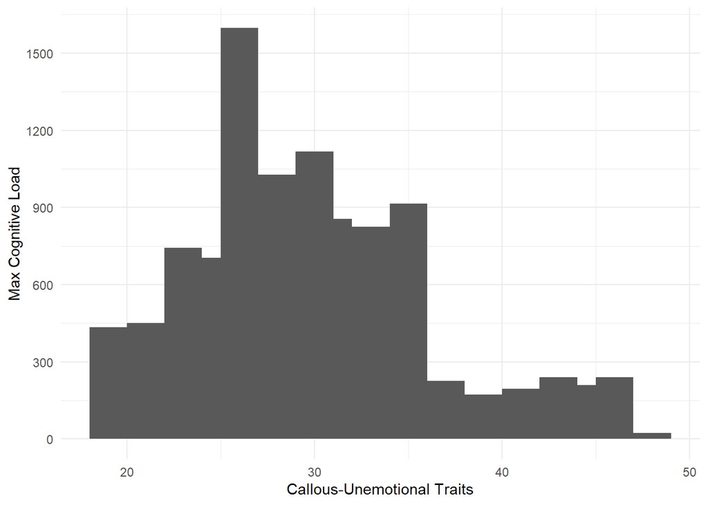

```r
ggplot(T2_dat,aes(x=icu_total, y= load2_max))+
  geom_col(width = 2) +
  scale_y_continuous("Max Cognitive Load",
                     n.breaks = 8,
                     labels = c("0","300","600","900","1200","1500","1800")) +
  xlab("Callous-Unemotional Traits") +
  xlim(18,49) +
  theme_minimal()
```

```r
#ggsave(path = "C:\\Users\\wintersd\\OneDrive - The University of Colorado Denver\\DPRG main project\\Analyses and Data\\full_data_87\\1_Paper-1", width = 3, height = 3, filename = "max_load_dist_CU.tiff", device='tiff', dpi=700, limitsize = FALSE)
```

#### 6.3.1.1 count stats

```r
max_count <- T2_dat %>% group_by( load2_max) %>% summarize(count = n())

max_count[1:21,]
```

| load2_max | count |
| --- | --- |
| 150 | 6 |
| 200 | 3 |
| 250 | 1 |
| 300 | 3 |
| 350 | 3 |
| 400 | 2 |
| 500 | 1 |
| 550 | 1 |
| 600 | 3 |
| 700 | 3 |

[output cut: 11 more lines]

```r
# maximum and min count for duration of CL
data.frame(rbind(max_count=max_count[which(max_count$count==max(max_count$count)),],min_count=max_count[which(max_count$count==min(max_count$count)),]))
```

|  | load2_max | count |
| --- | --- | --- |
| max_count | 1600 | 17 |
| min_count.1 | 250 | 1 |
| min_count.2 | 500 | 1 |
| min_count.3 | 550 | 1 |
| min_count.4 | 800 | 1 |
| min_count.5 | 850 | 1 |
| min_count.6 | 1100 | 1 |
| min_count.7 | 1150 | 1 |

# 7 Change in mind in the eyes task - Identifying complex emotions

## 7.1 Multilevel model comparing mean differneces form T1-T2

> doesnt matter if I control for CD or not

### 7.1.1 for ICU total

```r
T2_dat_long2 <- tidyr::gather(T2_dat[-c(which(T2_dat$bad_load_2==1)),][,which(colnames(T2_dat) %in% c("record_id", "mie2_complex", "mie1_complex","icu_unemotional" ,"icu_total" , "bad_resp2", "sex_male", "age", "race_White", "anny2_diff","WAI_total","sdq_total_cd"))],time,value,mie1_complex,mie2_complex,mie1_complex:mie2_complex, factor_key=TRUE)

T2_dat_long2$time_rc <- as.numeric(car::recode(T2_dat_long2$time, "'mie2_complex'=1;'mie1_complex'=0"))


T2_dat_long2<-semTools::orthogonalize(T2_dat_long2, var1=c("icu_total", "time_rc"), var2=c("time_rc","icu_total"), match = TRUE)

llmod3<-lmer(value~ icu_total +
               time_rc +
               icu_total.time_rc +
               anny2_diff +
               sex_male +
               age +
               sdq_total_cd +
               race_White +
               bad_resp2 +
               (1|record_id),
             data=T2_dat_long2)


reg2<- lm(value~icu_total* time +
            anny2_diff +
            sex_male +
            age +
            race_White+
            sdq_total_cd +
            bad_resp2,
          data=T2_dat_long2)


lrtest(reg2,llmod3)
```

|  | #Df | LogLik | Df | Chisq | Pr(>Chisq) |
| --- | --- | --- | --- | --- | --- |
| 1 | 10 | -339.5793 | NA | NA | NA |
| 2 | 11 | -334.7625 | 1 | 9.633594 | 0.001910504 |

> The addition of a random effect did improve model fit to the data - plausibly due to the random effect accounting for cluster confounding

```r
anova(llmod3)
```

|  | Sum Sq | Mean Sq | NumDF | DenDF | F value | Pr(>F) |
| --- | --- | --- | --- | --- | --- | --- |
| icu_total | 15.2312351 | 15.2312351 | 1 | 65.00000 | 5.16480708 | 0.02636325 |
| time_rc | 9.0000000 | 9.0000000 | 1 | 70.00000 | 3.05183810 | 0.08503189 |
| icu_total.time_rc | 13.5670246 | 13.5670246 | 1 | 70.00000 | 4.60048473 | 0.03543519 |
| anny2_diff | 6.7883835 | 6.7883835 | 1 | 64.99999 | 2.30189417 | 0.13406514 |
| sex_male | 7.1682827 | 7.1682827 | 1 | 65.00000 | 2.43071536 | 0.12383459 |
| age | 1.7117937 | 1.7117937 | 1 | 64.99996 | 0.58045748 | 0.44888873 |
| sdq_total_cd | 0.2164056 | 0.2164056 | 1 | 65.00000 | 0.07338164 | 0.78733366 |
| race_White | 2.0997394 | 2.0997394 | 1 | 65.00000 | 0.71200720 | 0.40187303 |
| bad_resp2 | NA | NA | NA | NA | NA | NA |

```r
summary(llmod3)
```

```
## Linear mixed model fit by REML. t-tests use Satterthwaite's method [
## lmerModLmerTest]
## Formula: value ~ icu_total + time_rc + icu_total.time_rc + anny2_diff +
##     sex_male + age + sdq_total_cd + race_White + bad_resp2 +
##     (1 | record_id)
##    Data: T2_dat_long2
##
## REML criterion at convergence: 669.5
##
## Scaled residuals:
##     Min      1Q  Median      3Q     Max
## -2.5840 -0.4637  0.1014  0.5263  1.8662
##
## Random effects:
##  Groups    Name        Variance Std.Dev.
##  record_id (Intercept) 4.186    2.046
##  Residual              2.949    1.717
## Number of obs: 144, groups:  record_id, 72
##
## Fixed effects:
##                    Estimate Std. Error        df t value Pr(>|t|)
## (Intercept)       13.720352   5.465865 65.807114   2.510   0.0145 *
## icu_total         -0.126553   0.055686 64.999996  -2.273   0.0264 *
## time_rc           -0.500000   0.286213 70.000002  -1.747   0.0850 .
## icu_total.time_rc -0.099758   0.046510 70.000002  -2.145   0.0354 *
## anny2_diff         0.013798   0.009094 64.999995   1.517   0.1341
## sex_male          -0.898773   0.576478 64.999997  -1.559   0.1238
## age                0.299862   0.393583 64.999964   0.762   0.4489
## sdq_total_cd       0.059335   0.219038 64.999997   0.271   0.7873
## race_White        -0.552671   0.654975 64.999997  -0.844   0.4019
## ---
## Signif. codes:  0 '***' 0.001 '**' 0.01 '*' 0.05 '.' 0.1 ' ' 1
##
## Correlation of Fixed Effects:
##             (Intr) ic_ttl tim_rc ic_t._ anny2_ sex_ml age    sdq_t_
## icu_total   -0.288
## time_rc     -0.079  0.000
## ic_ttl.tm_r  0.000  0.000  0.000
## anny2_diff  -0.265  0.139  0.000  0.000
## sex_male     0.001  0.111  0.000  0.000 -0.046
## age         -0.946 -0.005  0.000  0.000  0.204 -0.074
## sdq_totl_cd  0.084 -0.542  0.000  0.000  0.086 -0.208  0.047
## race_White  -0.142  0.096  0.000  0.000 -0.255 -0.011  0.056 -0.193
## fit warnings:
## fixed-effect model matrix is rank deficient so dropping 1 column / coefficient
```

#### 7.1.1.1 R2 for model

```r
round(MuMIn::r.squaredGLMM(llmod3),3)
```

```
##        R2m   R2c
## [1,] 0.146 0.647
```

#### 7.1.1.2 R2 for each IV

```r
r2glmm::r2beta(llmod3)
```

|  | Effect | F | v1 | v2 | ncp | Rsq | upper.CL | lower.CL |
| --- | --- | --- | --- | --- | --- | --- | --- | --- |
| 1 | Model | 3.0588211 | 8 | 140 | 24.4705692 | 0.1487838785 | 0.29728693 | 9.141726e-02 |
| 2 | icu_total | 8.1948857 | 1 | 140 | 8.1948857 | 0.0552980329 | 0.14707428 | 5.789723e-03 |
| 6 | sex_male | 3.8567625 | 1 | 140 | 3.8567625 | 0.0268097409 | 0.10188833 | 3.190918e-04 |
| 5 | anny2_diff | 3.6523648 | 1 | 140 | 3.6523648 | 0.0254250238 | 0.09940525 | 2.626970e-04 |
| 4 | icu_total.time_rc | 1.9014816 | 1 | 140 | 1.9014816 | 0.0134000126 | 0.07562633 | 4.702644e-05 |
| 3 | time_rc | 1.2613919 | 1 | 140 | 1.2613919 | 0.0089294879 | 0.06510904 | 2.483679e-05 |
| 9 | race_White | 1.1297261 | 1 | 140 | 1.1297261 | 0.0080048773 | 0.06273035 | 2.177659e-05 |
| 7 | age | 0.9209991 | 1 | 140 | 0.9209991 | 0.0065355703 | 0.05875049 | 1.767782e-05 |
| 8 | sdq_total_cd | 0.1164330 | 1 | 140 | 0.1164330 | 0.0008309735 | 0.03917470 | 7.909123e-06 |

#### 7.1.1.3 Confidence intervals

```r
confint(llmod3)
```

```
##                          2.5 %       97.5 %
## .sig01             1.484048092  2.413240417
## .sigma             1.450274789  2.012510427
## (Intercept)        3.403568311 24.037136006
## icu_total         -0.231652438 -0.021453070
## time_rc           -1.060581136  0.060581133
## icu_total.time_rc -0.190852237 -0.008662831
## anny2_diff        -0.003366387  0.030961729
## sex_male          -1.986799623  0.189254313
## age               -0.442974255  1.042698254
## sdq_total_cd      -0.354069868  0.472740343
## race_White        -1.788850628  0.683508212
```

##### 7.1.1.3.1 Bootstrapped CIs

```r
set.seed(101)
gg<- lmeresampler::bootstrap(llmod3, .f = fixef, type = "parametric", B = 5000)
bb<-confint(gg, type = "norm")
bb
```

| term | estimate | lower | upper | type | level |
| --- | --- | --- | --- | --- | --- |
| (Intercept) | 13.72035218 | 3.213184989 | 24.306353566 | norm | 0.95 |
| icu_total | -0.12655275 | -0.236142898 | -0.016862419 | norm | 0.95 |
| time_rc | -0.50000000 | -1.062164813 | 0.060142879 | norm | 0.95 |
| icu_total.time_rc | -0.09975753 | -0.190019858 | -0.009492715 | norm | 0.95 |
| anny2_diff | 0.01379767 | -0.003684063 | 0.031400404 | norm | 0.95 |
| sex_male | -0.89877265 | -2.008780988 | 0.227207493 | norm | 0.95 |
| age | 0.29986200 | -0.467428862 | 1.058480424 | norm | 0.95 |
| sdq_total_cd | 0.05933524 | -0.364140323 | 0.485925128 | norm | 0.95 |
| race_White | -0.55267121 | -1.851830563 | 0.754622382 | norm | 0.95 |

### 7.1.2 unemotional subscale

```r
T2_dat_long2 <- tidyr::gather(T2_dat[-c(which(T2_dat$bad_load_2==1)),][,which(colnames(T2_dat) %in% c("record_id", "mie2_complex", "mie1_complex","icu_unemotional" , "bad_resp2","icu_total" ,"sex_male", "age", "race_White", "anny2_diff","WAI_total","sdq_total_cd"))],time,value,mie1_complex,mie2_complex,mie1_complex:mie2_complex, factor_key=TRUE)

T2_dat_long2$time_rc <- as.numeric(car::recode(T2_dat_long2$time, "'mie2_complex'=1;'mie1_complex'=0"))

T2_dat_long2<-semTools::orthogonalize(T2_dat_long2, var1=c("icu_unemotional", "time_rc"), var2=c("time_rc","icu_unemotional"), match = TRUE)


llmod2<-lmer(value~ icu_unemotional +
               time_rc +
               icu_unemotional.time_rc +
               anny2_diff +
               sex_male +
               age +
               race_White+
               sdq_total_cd+
               bad_resp2+
               (1|record_id),
             data=T2_dat_long2)



reg1<- lm(value~icu_unemotional.time_rc +
            icu_unemotional +
            time_rc +
            anny2_diff +
            sex_male +
            age +
            race_White+
            sdq_total_cd+
            bad_resp2,
          data=T2_dat_long2)
```

#### 7.1.2.1 LR test to see if random effects improves model estimation

```r
lrtest(reg1,llmod2)
```

|  | #Df | LogLik | Df | Chisq | Pr(>Chisq) |
| --- | --- | --- | --- | --- | --- |
| 1 | 10 | -341.0044 | NA | NA | NA |
| 2 | 11 | -332.5119 | 1 | 16.98509 | 3.767459e-05 |

> the addition of a random effect did improve model fit to the data - plausibly due to the random effect accounting for cluster confounding

#### 7.1.2.2 Mean differences for random effects model

```r
anova(llmod2)
```

|  | Sum Sq | Mean Sq | NumDF | DenDF | F value | Pr(>F) |
| --- | --- | --- | --- | --- | --- | --- |
| icu_unemotional | 7.9944743 | 7.9944743 | 1 | 65.00000 | 2.8031292 | 0.098886206 |
| time_rc | 9.0000000 | 9.0000000 | 1 | 70.00000 | 3.1557001 | 0.080007504 |
| icu_unemotional.time_rc | 20.3612480 | 20.3612480 | 1 | 70.00000 | 7.1393324 | 0.009373337 |
| anny2_diff | 7.9331089 | 7.9331089 | 1 | 65.00000 | 2.7816125 | 0.100163257 |
| sex_male | 6.0405311 | 6.0405311 | 1 | 65.00000 | 2.1180116 | 0.150388259 |
| age | 2.1086896 | 2.1086896 | 1 | 65.00001 | 0.7393769 | 0.393020943 |
| race_White | 0.7704609 | 0.7704609 | 1 | 65.00000 | 0.2701493 | 0.604997263 |
| sdq_total_cd | 0.5058509 | 0.5058509 | 1 | 65.00000 | 0.1773682 | 0.675034166 |
| bad_resp2 | NA | NA | NA | NA | NA | NA |

> we see a ICU/time interaction suggesting that yes there is a differnece from T1-T2

#### 7.1.2.3 Model estimates

```r
summary(llmod2)
```

```
## Linear mixed model fit by REML. t-tests use Satterthwaite's method [
## lmerModLmerTest]
## Formula: value ~ icu_unemotional + time_rc + icu_unemotional.time_rc +
##     anny2_diff + sex_male + age + race_White + sdq_total_cd +
##     bad_resp2 + (1 | record_id)
##    Data: T2_dat_long2
##
## REML criterion at convergence: 665
##
## Scaled residuals:
##     Min      1Q  Median      3Q     Max
## -2.3292 -0.5285  0.1167  0.5698  1.9942
##
## Random effects:
##  Groups    Name        Variance Std.Dev.
##  record_id (Intercept) 4.432    2.105
##  Residual              2.852    1.689
## Number of obs: 144, groups:  record_id, 72
##
## Fixed effects:
##                          Estimate Std. Error        df t value Pr(>|t|)
## (Intercept)             11.877411   5.423262 65.792822   2.190  0.03207 *
## icu_unemotional         -0.268861   0.160585 64.999996  -1.674  0.09889 .
## time_rc                 -0.500000   0.281464 70.000002  -1.776  0.08001 .
## icu_unemotional.time_rc -0.385995   0.144462 70.000002  -2.672  0.00937 **
## anny2_diff               0.015337   0.009196 64.999997   1.668  0.10016
## sex_male                -0.852560   0.585815 64.999996  -1.455  0.15039
## age                      0.345220   0.401479 65.000012   0.860  0.39302
## race_White              -0.345280   0.664307 64.999997  -0.520  0.60500
## sdq_total_cd            -0.084946   0.201699 64.999996  -0.421  0.67503
## ---
## Signif. codes:  0 '***' 0.001 '**' 0.01 '*' 0.05 '.' 0.1 ' ' 1
##
## Correlation of Fixed Effects:
##             (Intr) ic_nmt tim_rc ic_n._ anny2_ sex_ml age    rc_Wht
## icu_unemtnl -0.192
## time_rc     -0.078  0.000
## ic_nmtnl.t_  0.000  0.000  0.000
## anny2_diff  -0.249  0.086  0.000  0.000
## sex_male     0.014  0.101  0.000  0.000 -0.053
## age         -0.955 -0.074  0.000  0.000  0.199 -0.081
## race_White  -0.106 -0.058  0.000  0.000 -0.276 -0.028  0.061
## sdq_totl_cd -0.010 -0.372  0.000  0.000  0.147 -0.202  0.077 -0.135
## fit warnings:
## fixed-effect model matrix is rank deficient so dropping 1 column / coefficient
```

#### 7.1.2.4 R2 for entire model

```r
round(MuMIn::r.squaredGLMM(llmod2),3)
```

```
##       R2m   R2c
## [1,] 0.13 0.659
```

#### 7.1.2.5 R2 by each IV

```r
r2glmm::r2beta(llmod2)
```

|  | Effect | F | v1 | v2 | ncp | Rsq | upper.CL | lower.CL |
| --- | --- | --- | --- | --- | --- | --- | --- | --- |
| 1 | Model | 2.6731285 | 8 | 140 | 21.3850277 | 0.132509366 | 0.28060916 | 8.030206e-02 |
| 2 | icu_unemotional | 4.5086602 | 1 | 140 | 4.5086602 | 0.031199931 | 0.10952256 | 5.817248e-04 |
| 5 | anny2_diff | 4.4740518 | 1 | 140 | 4.4740518 | 0.030967857 | 0.10912726 | 5.640054e-04 |
| 6 | sex_male | 3.4066908 | 1 | 140 | 3.4066908 | 0.023755452 | 0.09635669 | 2.073701e-04 |
| 4 | icu_unemotional.time_rc | 2.7954898 | 1 | 140 | 2.7954898 | 0.019576877 | 0.08842302 | 1.140981e-04 |
| 3 | time_rc | 1.2356516 | 1 | 140 | 1.2356516 | 0.008748864 | 0.06465110 | 2.420655e-05 |
| 7 | age | 1.1892420 | 1 | 140 | 1.1892420 | 0.008423036 | 0.06381693 | 2.311027e-05 |
| 8 | race_White | 0.4345184 | 1 | 140 | 0.4345184 | 0.003094100 | 0.04802756 | 1.087058e-05 |
| 9 | sdq_total_cd | 0.2852858 | 1 | 140 | 0.2852858 | 0.002033612 | 0.04412116 | 9.363829e-06 |

#### 7.1.2.6 Bootstrapped confidence intervals

```r
set.seed(101)
ff<- lmeresampler::bootstrap(llmod2, .f = fixef, type = "parametric", B = 5000)
aa<-confint(ff, type = "norm")
aa
```

| term | estimate | lower | upper | type | level |
| --- | --- | --- | --- | --- | --- |
| (Intercept) | 11.87741129 | 1.406544313 | 22.41478816 | norm | 0.95 |
| icu_unemotional | -0.26886080 | -0.582777985 | 0.04756019 | norm | 0.95 |
| time_rc | -0.50000000 | -1.052836291 | 0.05084791 | norm | 0.95 |
| icu_unemotional.time_rc | -0.38599522 | -0.665427255 | -0.10429655 | norm | 0.95 |
| anny2_diff | 0.01533725 | -0.002294782 | 0.03310885 | norm | 0.95 |
| sex_male | -0.85256005 | -1.981176861 | 0.29300738 | norm | 0.95 |
| age | 0.34522001 | -0.437679038 | 1.11883997 | norm | 0.95 |
| race_White | -0.34527960 | -1.661369926 | 0.97793745 | norm | 0.95 |
| sdq_total_cd | -0.08494589 | -0.475588697 | 0.30797449 | norm | 0.95 |

### 7.1.3 figures

#### 7.1.3.1 ICU unemotional change T1 and T2

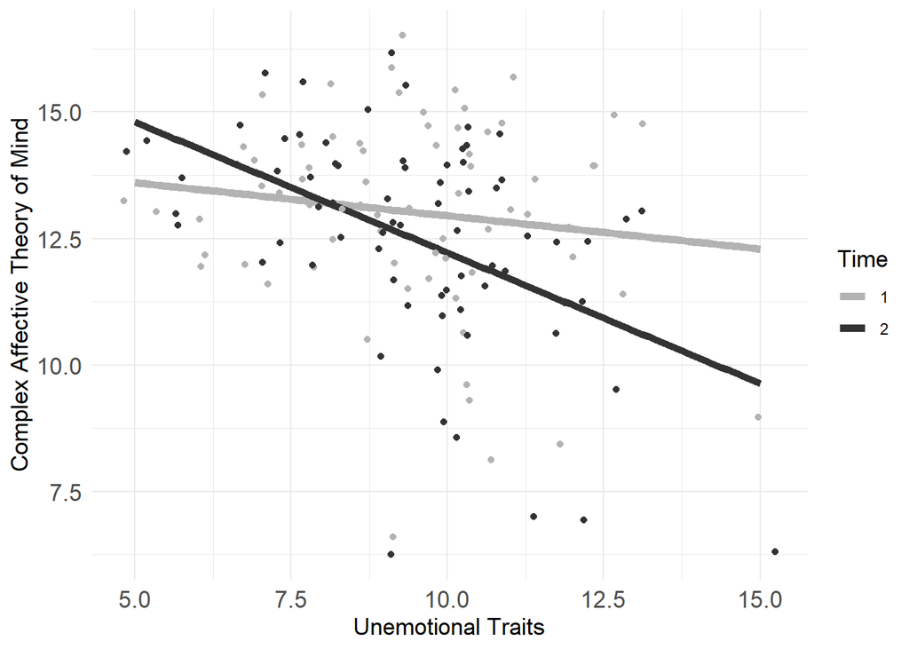

```r
T2_dat_long22<-T2_dat_long2[complete.cases(T2_dat_long2),]
T2_dat_long22$random.intercpet.preds <- predict(llmod2)
T2_dat_long22$time_rc<-car::recode(T2_dat_long22$time,"'mie2_complex'=2;'mie1_complex'=1", as.factor = FALSE)
T2_dat_long22$hi_lo<-ifelse(T2_dat_long22$icu_unemotional>mean(T2_dat_long22$icu_unemotional),"ICU Unemotional > Mean","ICU Unemotional < Mean")

ggplot(data=T2_dat_long22, aes(x=icu_unemotional, y=random.intercpet.preds, group = factor(time_rc), colour = factor(time_rc))) +
  geom_smooth(method='lm', formula = 'y~x',se=FALSE, size=2) + geom_jitter()+
  labs(x="Unemotional Traits", y="Complex Affective Theory of Mind") +
  scale_colour_grey("Time", start = .7, end= .2)  + theme_minimal() +
  theme(axis.text=element_text(size=rel(1.2)),axis.title=element_text(size=rel(1.2)), legend.title = element_text(colour = "black",size=rel(1.2)))
```

```r
## 500x500 or 5 x 5 in "in" units
#ggsave(path = "C:\\Users\\wintersd\\OneDrive - The University of Colorado Denver\\DPRG main project\\Analyses and Data\\full_data_87\\1_Paper-1", width = 6, height = 5, filename = "unemotional_time_lines.tiff", device='tiff', dpi=700, limitsize = FALSE)
```

> A sharper decrease in identifying complex emotions at higher unemotional traits

#### 7.1.3.2 ICU total change T1 and T2

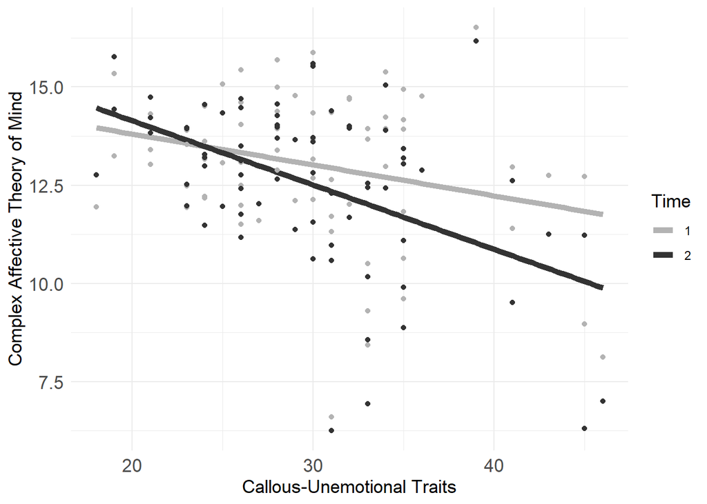

```r
T2_dat_long22$hi_lo2<-ifelse(T2_dat_long22$icu_total>mean(T2_dat_long22$icu_total),"ICU total > Mean","ICU total < Mean")

ggplot(data=T2_dat_long22, aes(x=icu_total, y=random.intercpet.preds, group = factor(time_rc), colour = factor(time_rc))) +
  geom_smooth(method='lm', formula = 'y~x',se=FALSE, size=2) + geom_point()+
  labs(x="Callous-Unemotional Traits", y="Complex Affective Theory of Mind") +
  scale_colour_grey("Time", start = .7, end= .2)  + theme_minimal() +
  theme(axis.text=element_text(size=rel(1.2)),axis.title=element_text(size=rel(1.2)), legend.title = element_text(colour = "black",size=rel(1.2)))
```

```r
## 500x500 or 5 x 5 in "in" units
#ggsave(path = "C:\\Users\\wintersd\\OneDrive - The University of Colorado Denver\\DPRG main project\\Analyses and Data\\full_data_87\\1_Paper-1", width = 6, height = 5, filename = "CU_time_lines.tiff", device='tiff', dpi=700, limitsize = FALSE)
```

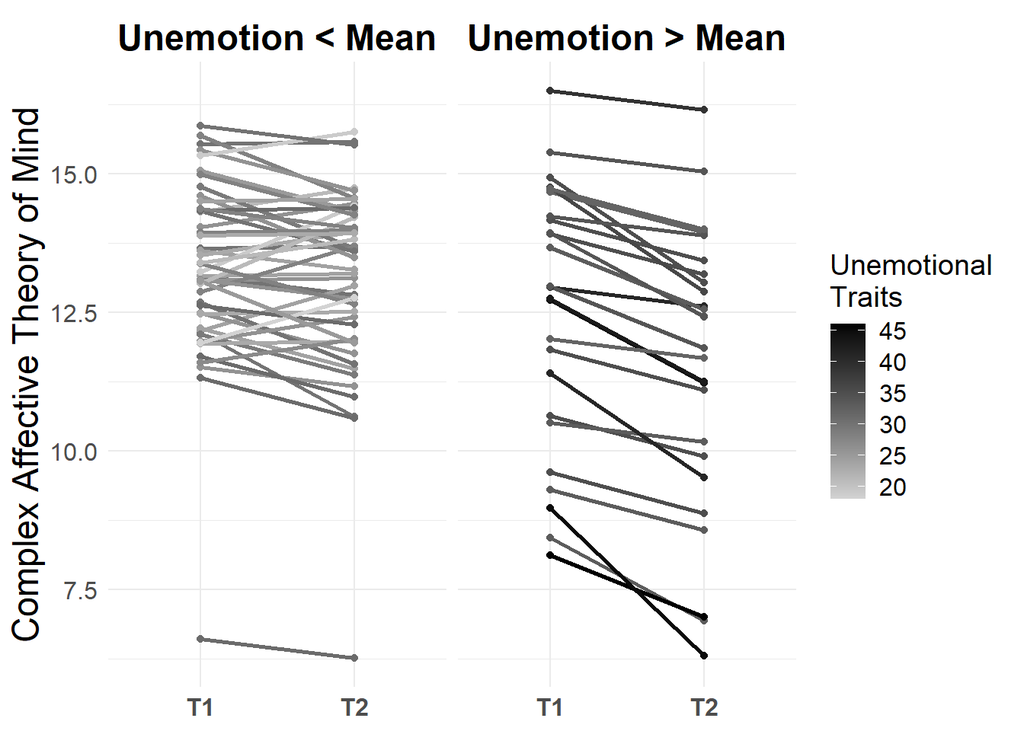

```r
T2_dat_long22$hi_lo2<-ifelse(T2_dat_long22$icu_total>(mean(T2_dat_long22$icu_total)+1.5),"Unemotion > Mean","Unemotion < Mean")

T1 <- expression(paste(bold("T1")))
T2 <- expression(paste(bold("T2")))

T2_dat_long22 %>%
  mutate(hi_lo = fct_relevel(hi_lo2, "Unemotional < Mean","Unemotional > Mean")) %>%
  ggplot(aes(x=factor(time), y=random.intercpet.preds, group = record_id, colour = icu_total)) +
  geom_smooth(method='lm',formula ='y ~ x') + geom_point()+
  labs(x=NULL, y="Complex Affective Theory of Mind") +
  scale_colour_gradient("Unemotional \nTraits", low="light grey",high="black") + facet_wrap(~hi_lo)  + scale_x_discrete(labels=c(T1, T2)) + theme_minimal() +
  theme(axis.text=element_text(size=rel(1.1)),axis.title=element_text(size=rel(1.6)), strip.text.x = element_text(colour = "black", face = "bold",size=rel(2)), legend.title = element_text(size=rel(1.3)), legend.text = element_text(size=rel(1.1)))
```

```r
## 500x500 or 5 x 5 in "in" units
#ggsave(path = "C:\\Users\\wintersd\\OneDrive - The University of Colorado Denver\\DPRG main project\\Analyses and Data\\full_data_87\\1_Paper-1", width = 6, height = 5, filename = "aff_load_unemotional.tiff", device='tiff', dpi=700, limitsize = FALSE)
```

#### 7.1.3.4 ICU total change random eff

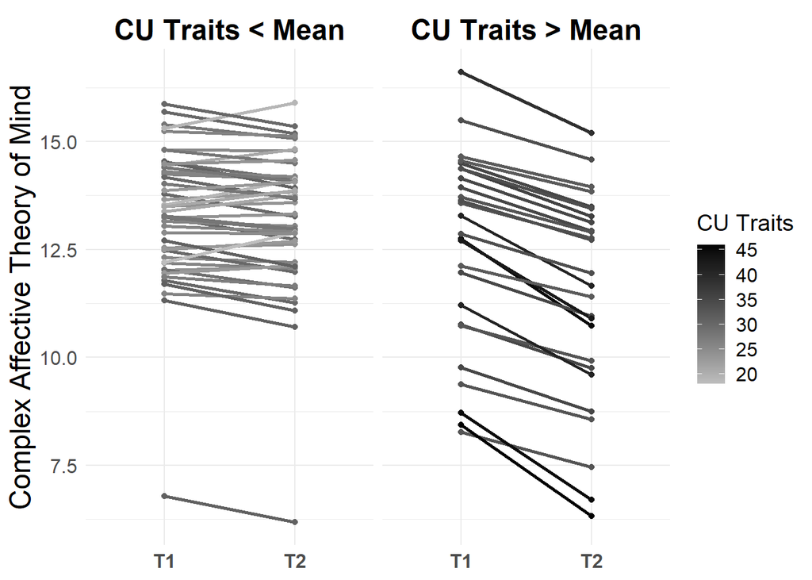

```r
T2_dat_long2 <- tidyr::gather(T2_dat[-c(which(T2_dat$bad_load_2==1),c(41,7,5,29,40)),][,which(colnames(T2_dat) %in% c("record_id", "mie2_complex", "mie1_complex","icu_unemotional" ,"icu_total" , "sex_male", "age", "race_White", "anny2_diff","WAI_total","sdq_total_cd"))],time,value,mie1_complex,mie2_complex,mie1_complex:mie2_complex, factor_key=TRUE)

llmod3<-lmer(value~icu_total * time + anny2_diff + sex_male + age + race_White +(1|record_id),data=T2_dat_long2)
T2_dat_long22$random.intercpet.preds3 <- predict(llmod3)

T2_dat_long22$hi_lo2<-ifelse(T2_dat_long22$icu_total>(mean(T2_dat_long22$icu_total)+1.5),"CU Traits > Mean","CU Traits < Mean")

T1 <- expression(paste(bold("T1")))
T2 <- expression(paste(bold("T2")))

T2_dat_long22 %>%
  mutate(hi_lo = fct_relevel(hi_lo2, "CU Traits < Mean","CU Traits > Mean")) %>%
  ggplot(aes(x=factor(time), y=random.intercpet.preds3, group = record_id, colour = icu_total)) +
  geom_smooth(method='lm',formula ='y ~ x') + geom_point()+
  labs(x=NULL, y="Complex Affective Theory of Mind") +
  scale_colour_gradient("CU Traits", low="grey",high="black") + facet_wrap(~hi_lo)  + scale_x_discrete(labels=c(T1, T2)) + theme_minimal() +
  theme(axis.text=element_text(size=rel(1.1)),axis.title=element_text(size=rel(1.6)), strip.text.x = element_text(colour = "black", face = "bold",size=rel(2)), legend.title = element_text(size=rel(1.3)), legend.text = element_text(size=rel(1.1)))
```

```r
## 500x500 or 5 x 5 in "in" units
#ggsave(path = "C:\\Users\\wintersd\\OneDrive - The University of Colorado Denver\\DPRG main project\\Analyses and Data\\full_data_87\\1_Paper-1", width = 6, height = 5, filename = "aff_load_totalCU.tiff", device='tiff', dpi=700, limitsize = FALSE)
```

## 7.2 Examining level of cognitive load

```r
T2_dat_long4 <- tidyr::gather(T2_dat[-c(which(T2_dat$bad_load_2==1)),][,which(colnames(T2_dat) %in% c("record_id", "mie2_complex", "mie1_complex","icu_unemotional" ,"icu_total" , "bad_resp2", "sex_male", "age", "race_White", "anny2_diff","WAI_total","sdq_total_cd","load2_max"))],time,value,mie1_complex,mie2_complex,mie1_complex:mie2_complex, factor_key=TRUE)

T2_dat_long4$time_rc <- as.numeric(car::recode(T2_dat_long4$time, "'mie2_complex'=1;'mie1_complex'=0"))


llmod4<-lmer(value~
               factor(load2_max)*icu_total*time_rc +
               (1|record_id),
             data=T2_dat_long4)
summary(llmod4)
```

```
## Linear mixed model fit by REML. t-tests use Satterthwaite's method [
## lmerModLmerTest]
## Formula: value ~ factor(load2_max) * icu_total * time_rc + (1 | record_id)
##    Data: T2_dat_long4
##
## REML criterion at convergence: 455.8
##
## Scaled residuals:
##     Min      1Q  Median      3Q     Max
## -1.8841 -0.1149  0.0000  0.2324  1.8548
##
## Random effects:
##  Groups    Name        Variance Std.Dev.
##  record_id (Intercept) 2.494    1.579
##  Residual              2.253    1.501
## Number of obs: 144, groups:  record_id, 72
##
## Fixed effects:
##                                           Estimate Std. Error         df
## (Intercept)                               20.26526   12.98262   60.44011
## factor(load2_max)200                     -82.26526   28.05979   60.44007
## factor(load2_max)250                       4.42737    5.76143   60.44009
## factor(load2_max)300                       5.19628   17.27895   60.44009
## factor(load2_max)350                      21.73474   36.57893   60.44007
## factor(load2_max)400                    -138.26526   45.25814   60.44007
## factor(load2_max)500                       1.58737    4.82577   60.44007
## factor(load2_max)550                      -3.13474    5.31151   60.44009
## factor(load2_max)600                     -39.97955   26.40581   60.44008
## factor(load2_max)700                       5.64383   19.32184   60.44009
## factor(load2_max)800                       4.30316    4.91497   60.44008
## factor(load2_max)850                       2.77053    6.51192   60.44010
## factor(load2_max)1000                    -15.26526   18.63890   60.44009
## factor(load2_max)1100                      3.96000    4.45109   60.44007
## factor(load2_max)1150                      4.71158    4.29207   60.44007
## factor(load2_max)1200                     -9.61661   21.77209   60.44008
## factor(load2_max)1300                     -8.08656   14.77473   60.44010
## factor(load2_max)1350                    -75.26526  176.22802   60.44008
## factor(load2_max)1400                    -17.27172   15.67242   60.44010
## factor(load2_max)1500                    -10.92096   15.11823   60.44010
## factor(load2_max)1600                     -7.58030   13.56200   60.44011
```

[output cut: 109 more lines]

```
## factor(load2_max)350:icu_total:time_rc    0.534  0.59676
## factor(load2_max)400:icu_total:time_rc   -2.339  0.02487 *
## factor(load2_max)600:icu_total:time_rc   -1.133  0.26444
## factor(load2_max)700:icu_total:time_rc   -0.188  0.85161
## factor(load2_max)1000:icu_total:time_rc  -0.464  0.64558
## factor(load2_max)1200:icu_total:time_rc  -0.665  0.51002
## factor(load2_max)1300:icu_total:time_rc  -0.378  0.70743
## factor(load2_max)1350:icu_total:time_rc   0.644  0.52364
## factor(load2_max)1400:icu_total:time_rc  -0.967  0.33975
## factor(load2_max)1500:icu_total:time_rc  -0.084  0.93346
## factor(load2_max)1600:icu_total:time_rc  -1.042  0.30427
## ---
## Signif. codes:  0 '***' 0.001 '**' 0.01 '*' 0.05 '.' 0.1 ' ' 1
## fit warnings:
## fixed-effect model matrix is rank deficient so dropping 14 columns / coefficients
```

```r
z<-data.frame(r2glmm::r2beta(llmod4))[,c(1,6)]
z$Rsq<-round(z$Rsq,3)*100

z[grepl("\\d+:icu_total:time_rc" , z$Effect  ),]
```

|  | Effect | Rsq |
| --- | --- | --- |
| 58 | factor(load2_max)200:icu_total:time_rc | 3.4 |
| 61 | factor(load2_max)400:icu_total:time_rc | 1.8 |
| 62 | factor(load2_max)600:icu_total:time_rc | 0.4 |
| 70 | factor(load2_max)1600:icu_total:time_rc | 0.4 |
| 68 | factor(load2_max)1400:icu_total:time_rc | 0.3 |
| 65 | factor(load2_max)1200:icu_total:time_rc | 0.1 |
| 67 | factor(load2_max)1350:icu_total:time_rc | 0.1 |
| 60 | factor(load2_max)350:icu_total:time_rc | 0.1 |
| 64 | factor(load2_max)1000:icu_total:time_rc | 0.1 |
| 66 | factor(load2_max)1300:icu_total:time_rc | 0.0 |

[output cut: 3 more lines]

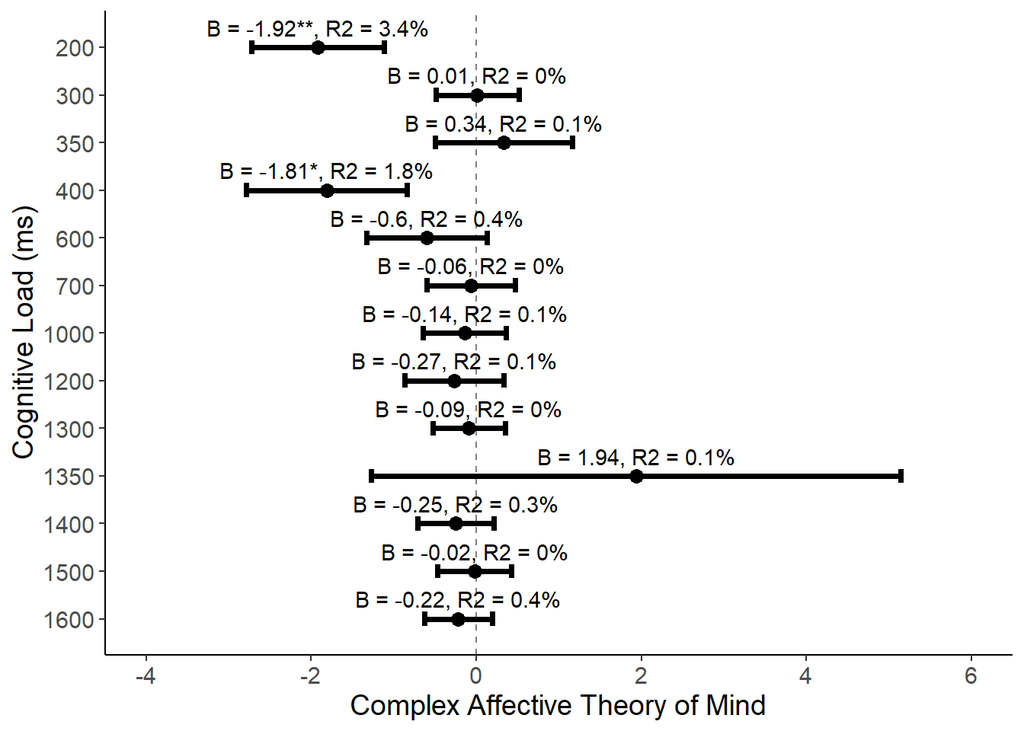

```r
eff<-llmod4@beta[58:70]
std.er<-c(0.59981,0.30210,0.63118,0.77534,0.52850,0.33528,0.30210,0.39964,0.23858,3.00819,0.25891,0.24698,0.20890)
hi<-eff+std.er+.2
lo<-eff-std.er-.2
index<-rep(1:13)
labels<-(as.numeric(levels(unique(llmod4@frame$`factor(load2_max)`)))[c(2,4,5,6,9,10,13,16:21)])
dd<-data.frame(index,labels,eff,std.er,hi,lo)

ggplot(dd,aes(y=index, x=eff, xmin=lo, xmax=hi))+
  geom_point()+ #this adds the effect sizes to the plot
  #this changes the features of the overall effects
  #one could resize, reshape, or recolor these points if desired
  geom_point(data=dd, color="Black", size=3)+
  geom_errorbarh(height=.3, size=1.25)+ #adds the CIs
  #sets the scales
  #note that I reverse the y axis to correctly order the effect #sizes based on my index variable
  scale_x_continuous(limits=c(-4,6), name="Complex Affective Theory of Mind")+
  scale_y_continuous(name = "Cognitive Load (ms)", breaks=1:13, labels = dd$labels, trans="reverse")+

  #adding a vertical line at the effect = 0 mark
  geom_vline(xintercept=0, color="black", linetype="dashed", alpha=.5)+
  geom_text(aes(label=paste0("B = ", round(eff,2),c("**","","","*","","","","","","","","",""),", R2 = ",z[grepl("\\d+:icu_total:time_rc" , z$Effect  ),]$Rsq[c(1,13,8,2,3,11,9,6,10,7,5,12,4)],"%")), vjust=-.7) +
  # adding a line at the overall effect size finding
  # geom_vline(xintercept=mean(dd$eff), color="black", linetype="solid", alpha=.5)+

  #faceting based on my subgroups
  #facet_grid(design~., scales= "free", space="free")+

  #thematic stuff
  #ggtitle("CU Traits and Alcohol Use Frequency")+
  theme_classic()+
  theme(text=element_text(size=14, color="black"))+
  theme(panel.spacing = unit(1, "lines"))
```

```r
## 500x500 or 7 x 4.5 in "in" units
#ggsave(path = "C:\\Users\\wintersd\\OneDrive - The University of Colorado Denver\\DPRG main project\\Analyses and Data\\full_data_87\\1_Paper-1", width = 6.5, height = 4.5, filename = "max_load_beta.tiff", device='tiff', dpi=700, limitsize = FALSE)
```

## 7.3 Showing analysis for basic

### 7.3.1 total CU

```r
T2_dat_long2 <- tidyr::gather(T2_dat[-c(which(T2_dat$bad_load_2==1)),][,which(colnames(T2_dat) %in% c("record_id", "mie2_basic", "mie1_basic","icu_unemotional" ,"icu_total" , "bad_resp2", "sex_male", "age", "race_White", "anny2_diff","WAI_total","sdq_total_cd"))],time,value,mie1_basic,mie2_basic,mie1_basic:mie2_basic, factor_key=TRUE)

T2_dat_long2$time_rc <- as.numeric(car::recode(T2_dat_long2$time, "'mie2_basic'=1;'mie1_basic'=0"))


T2_dat_long2<-semTools::orthogonalize(T2_dat_long2, var1=c("icu_total", "time_rc"), var2=c("time_rc","icu_total"), match = TRUE)

llmod3<-lmer(value~ icu_total +
               time_rc +
               icu_total.time_rc +
               anny2_diff +
               sex_male +
               age +
               sdq_total_cd +
               race_White +
               bad_resp2 +
               (1|record_id),
             data=T2_dat_long2)

summary(llmod3)
```

```
## Linear mixed model fit by REML. t-tests use Satterthwaite's method [
## lmerModLmerTest]
## Formula: value ~ icu_total + time_rc + icu_total.time_rc + anny2_diff +
##     sex_male + age + sdq_total_cd + race_White + bad_resp2 +
##     (1 | record_id)
##    Data: T2_dat_long2
##
## REML criterion at convergence: 591.2
##
## Scaled residuals:
##      Min       1Q   Median       3Q      Max
## -2.05900 -0.52778  0.09616  0.60427  1.63395
##
## Random effects:
##  Groups    Name        Variance Std.Dev.
##  record_id (Intercept) 1.526    1.235
##  Residual              2.028    1.424
## Number of obs: 144, groups:  record_id, 72
##
## Fixed effects:
##                    Estimate Std. Error        df t value Pr(>|t|)
## (Intercept)        4.609396   3.667652 66.236810   1.257   0.2133
## icu_total         -0.026014   0.037305 64.999999  -0.697   0.4881
## time_rc           -0.263889   0.237337 70.000001  -1.112   0.2700
## icu_total.time_rc -0.005736   0.038567 70.000001  -0.149   0.8822
## anny2_diff         0.013286   0.006092 64.999999   2.181   0.0328 *
## sex_male          -0.569079   0.386189 64.999998  -1.474   0.1454
## age                0.253242   0.263666 65.000004   0.960   0.3404
## sdq_total_cd      -0.112088   0.146736 64.999998  -0.764   0.4477
## race_White        -0.171611   0.438775 64.999998  -0.391   0.6970
## ---
## Signif. codes:  0 '***' 0.001 '**' 0.01 '*' 0.05 '.' 0.1 ' ' 1
##
## Correlation of Fixed Effects:
##             (Intr) ic_ttl tim_rc ic_t._ anny2_ sex_ml age    sdq_t_
## icu_total   -0.288
## time_rc     -0.097  0.000
## ic_ttl.tm_r  0.000  0.000  0.000
## anny2_diff  -0.265  0.139  0.000  0.000
## sex_male     0.001  0.111  0.000  0.000 -0.046
## age         -0.944 -0.005  0.000  0.000  0.204 -0.074
## sdq_totl_cd  0.084 -0.542  0.000  0.000  0.086 -0.208  0.047
## race_White  -0.141  0.096  0.000  0.000 -0.255 -0.011  0.056 -0.193
## fit warnings:
## fixed-effect model matrix is rank deficient so dropping 1 column / coefficient
```

### 7.3.2 unemotional

```r
T2_dat_long2 <- tidyr::gather(T2_dat[-c(which(T2_dat$bad_load_2==1)),][,which(colnames(T2_dat) %in% c("record_id", "mie2_basic", "mie1_basic","icu_unemotional" ,"icu_total" , "bad_resp2", "sex_male", "age", "race_White", "anny2_diff","WAI_total","sdq_total_cd"))],time,value,mie1_basic,mie2_basic,mie1_basic:mie2_basic, factor_key=TRUE)

T2_dat_long2$time_rc <- as.numeric(car::recode(T2_dat_long2$time, "'mie2_basic'=1;'mie1_basic'=0"))


T2_dat_long2<-semTools::orthogonalize(T2_dat_long2, var1=c("icu_unemotional", "time_rc"), var2=c("time_rc","icu_unemotional"), match = TRUE)

llmod3<-lmer(value~ icu_unemotional +
               time_rc +
               icu_unemotional.time_rc +
               anny2_diff +
               sex_male +
               age +
               sdq_total_cd +
               race_White +
               bad_resp2 +
               (1|record_id),
             data=T2_dat_long2)

summary(llmod3)
```

```
## Linear mixed model fit by REML. t-tests use Satterthwaite's method [
## lmerModLmerTest]
## Formula: value ~ icu_unemotional + time_rc + icu_unemotional.time_rc +
##     anny2_diff + sex_male + age + sdq_total_cd + race_White +
##     bad_resp2 + (1 | record_id)
##    Data: T2_dat_long2
##
## REML criterion at convergence: 586.4
##
## Scaled residuals:
##      Min       1Q   Median       3Q      Max
## -2.19184 -0.54503  0.09652  0.60320  1.54057
##
## Random effects:
##  Groups    Name        Variance Std.Dev.
##  record_id (Intercept) 1.558    1.248
##  Residual              2.002    1.415
## Number of obs: 144, groups:  record_id, 72
##
## Fixed effects:
##                          Estimate Std. Error        df t value Pr(>|t|)
## (Intercept)              3.880747   3.591356 66.274032   1.081   0.2838
## icu_unemotional         -0.001211   0.106147 64.999998  -0.011   0.9909
## time_rc                 -0.263889   0.235837 70.000001  -1.119   0.2670
## icu_unemotional.time_rc  0.115809   0.121044 70.000001   0.957   0.3420
## anny2_diff               0.013870   0.006079 64.999999   2.282   0.0258 *
## sex_male                -0.539581   0.387223 64.999999  -1.393   0.1682
## age                      0.252544   0.265377 64.999999   0.952   0.3448
## sdq_total_cd            -0.167002   0.133323 64.999999  -1.253   0.2148
## race_White              -0.141902   0.439106 64.999999  -0.323   0.7476
## ---
## Signif. codes:  0 '***' 0.001 '**' 0.01 '*' 0.05 '.' 0.1 ' ' 1
##
## Correlation of Fixed Effects:
##             (Intr) ic_nmt tim_rc ic_n._ anny2_ sex_ml age    sdq_t_
## icu_unemtnl -0.191
## time_rc     -0.099  0.000
## ic_nmtnl.t_  0.000  0.000  0.000
## anny2_diff  -0.248  0.086  0.000  0.000
## sex_male     0.014  0.101  0.000  0.000 -0.053
## age         -0.953 -0.074  0.000  0.000  0.199 -0.081
## sdq_totl_cd -0.010 -0.372  0.000  0.000  0.147 -0.202  0.077
## race_White  -0.106 -0.058  0.000  0.000 -0.276 -0.028  0.061 -0.135
## fit warnings:
## fixed-effect model matrix is rank deficient so dropping 1 column / coefficient
```